# R Learning - Ch4. 資料視覺化

“Lun (P96044045@mail.ncku.edu.tw)”

2016/12/08

經過前三章的教學，想必你們已經對於初步的資料有相當的認識了。 而這個章節要來學習「更實用」，或者說，更生活化的技巧—**繪圖(Plotting)！**

「繪圖」最主要目的，是把密密麻麻的資料，轉化為各式各樣的圖表 e.g.點線(趨勢)圖、長條圖、圓餅圖、箱型圖、複合式圖表…，時常使用Excel的人，相信對圖表本身並不陌生。

然而，你有仔細思考過，為什麼要把資料畫成圖表嗎？

事實上，這樣的動作有一個專有名詞，叫做**資料視覺化(Data Visualization)** 其中，涉及的領域包括**藝術、設計、心理學、程式及軟體…**

毫無疑問，「資料視覺化」這個名詞，如今已經代表一門專業學科；在網路的社群上，也有來自各方人士的熱烈討論與研究。其中更是不乏資料視覺化相關的[教學軟體或是程式語言](http://infographics.tw/)~

相信各位都有跟長官報告的相關經驗~ 而你們覺得老闆很閒嗎?  
有很多的時間，去慢慢看你的數字嗎?

其實，「資料視覺化」最基本、最重要的概念，只有一句話：**「降低資料的理解門檻」**。

> 在2016/03/26，[資料科學愛好者年會所舉辦的活動](http://dsc.kktix.cc/events/data-vis)上，  
> 台大土木系的康仕仲教授以一張圖來解釋這樣的概念：

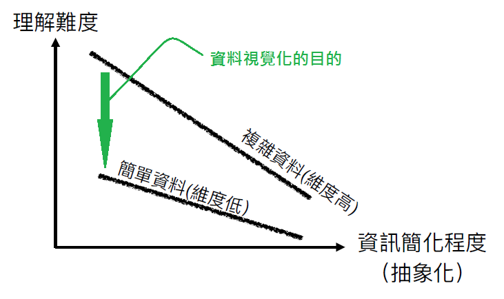

> 因此，「資料視覺化」可以在**保留原有資訊的情況下**，**降低複雜資料的理解難度**；也可以說，幫> 助我們**以較簡單的方式**，去**理解複雜的資料**。

資料分析前，我們需要**瀏覽資料(explore data)**，以理解資料的狀態；資料分析後，我們需要再把**分析結果呈現**出來，使人容易理解。

你會發現，針對以上這兩種情況，不管是瀏覽資料或是呈現結果，「資料視覺化」都佔了很重要的地位。因此，學好視覺化的技巧與適當的應用視覺化，絕對是有其必要性。

在R裡面，主要有三個強大的繪圖系統，包括**basic plot, lattice , and ggplot2**，可以幫助我們輕易達成「資料視覺化」的目的，以下將重點放在basic plot與ggplot2上~

# **1. Base Plotting System**

看到Base這個單字，就知道這是R最基本、最核心的繪圖系統。

但光是這最基本的繪圖系統，就包含了大部分常用的繪圖函式了！

以下會先以上個章節所使用的資料**weather**來進行說明：

```r
weather <- read.csv("C:/Users/Luuun/Dropbox/SDM/ex4/weather.csv")
head(weather)
```

```
##        CET Max.TemperatureC Mean.TemperatureC Min.TemperatureC Dew.PointC
## 1 1997-1-1                7                 4                2          5
## 2 1997-1-2                7                 3                0          6
## 3 1997-1-3                5                 3                2          5
## 4 1997-1-4                7                 3               -1         -2
## 5 1997-1-5                2                 0               -1          2
## 6 1997-1-6                7                 3                1          2
##   MeanDew.PointC Min.DewpointC Max.Humidity Mean.Humidity Min.Humidity
## 1              3             2          100            95           76
## 2              3             0          100            92           71
## 3              1            -1          100            85           70
## 4             -3            -4           86            63           49
## 5              0            -3          100            95           86
## 6             -1            -3          100            82           57
##   Max.Sea.Level.PressurehPa Mean.Sea.Level.PressurehPa
```

[output cut: 27 more lines]

## ‧hist()

```r
weather$year <- as.numeric(gsub("-(.*)", "", as.character(weather$CET)))
table(weather$year)
```

```
##
## 1997 1998 1999 2000 2001 2002 2003 2004 2005 2006 2007 2008 2009 2010 2011
##  365  365  365  269  365  365  365  336  365  365  365  366  365  365  365
## 2012 2013 2014 2015
##  366  365  365  365
```

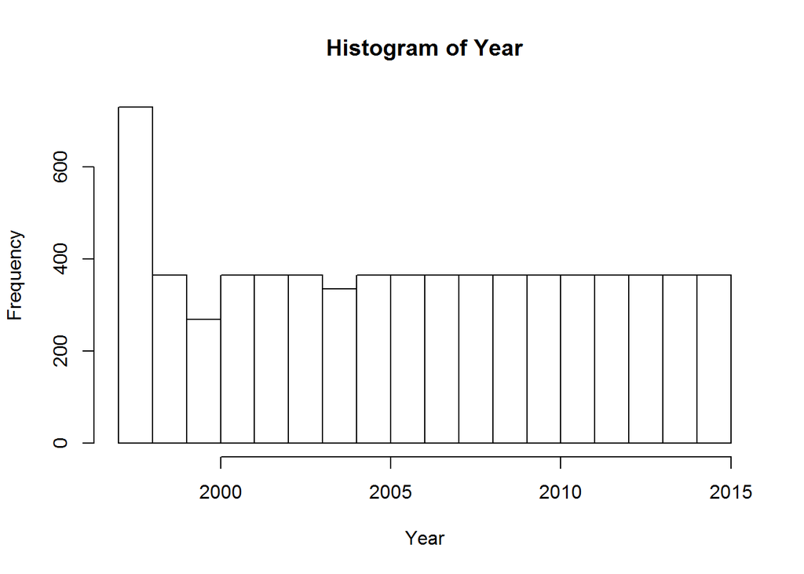

```r
hist(x=weather$year,
     main="Histogram of Year",         # 圖片的名稱
     xlab="Year",                      # X軸的名稱
     ylab="Frequency")                  # Y軸的名稱
```

## ‧boxplot()

這是畫**盒鬚圖(Box Plot)**的函式。  
當我們想要看資料裡面，不同年份的平均氣溫(Mean.TemperatureC)數值的分布情況，可以如下使用：

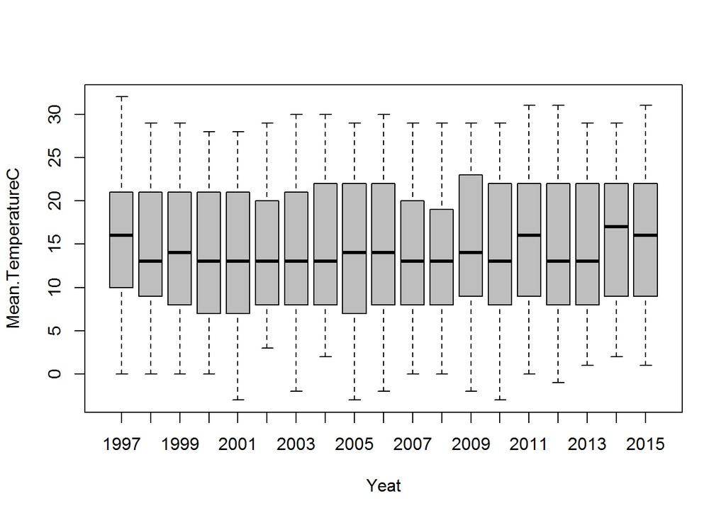

```r
boxplot(formula = Mean.TemperatureC ~ year, # Y ~ X (代表X和Y軸要放的數值)
        data = weather,       # 資料
        xlab = "Yeat",          # X軸名稱
        ylab = "Mean.TemperatureC",    # Y軸名稱
        col ="gray")             # 顏色
```

## ‧plot()

這是畫**散布圖(Scatter Plot)**的函式。  
當我們想要看年份(year)和平均氣溫(Mean.TemperatureC)之間的分布關係，可以這樣使用：

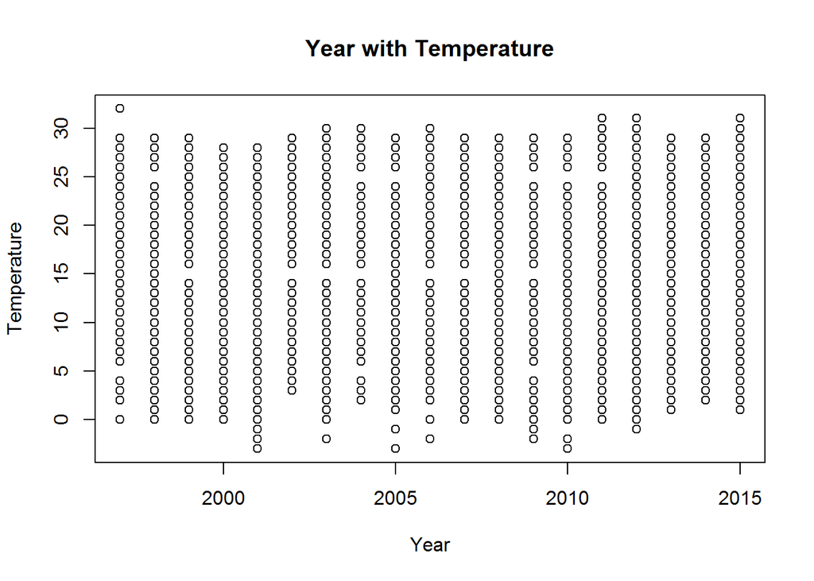

```r
plot(x=weather$year,            # X軸的值
     y=weather$Mean.TemperatureC,             # Y軸的值
     main="Year with Temperature",   # 圖片名稱
     xlab="Year",            # X軸名稱
     ylab="Temperature") # Y軸名稱
```

對應到上面的盒鬚圖，有發現其實兩種呈現的方式不同，但表達的意涵相近嗎?

或者，我們想要看平均氣溫和平均濕度之間的關係：

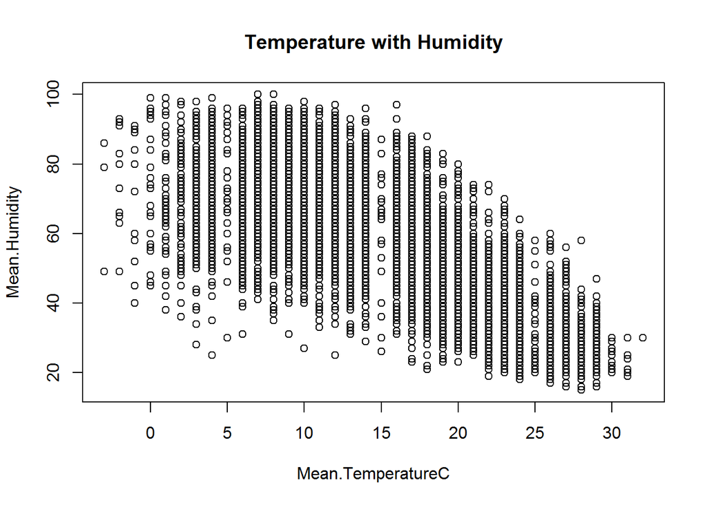

```r
plot(x=weather$Mean.TemperatureC,      # X軸的值
     y=weather$Mean.Humidity,       # Y軸的值
     main="Temperature with Humidity",    # 圖片名稱
     xlab="Mean.TemperatureC",       # X軸的名稱
     ylab="Mean.Humidity"         # Y軸的名稱
)
```

事實上，當我們使用`plot()`函式時，代表我們已經在R裡面建立了一塊「畫布」(canvas)~ 對，就是藝術家作畫的那種畫布！

既然是一塊畫布，就表示我們可以隨自己的意思，在畫布上面隨意地作畫，除了我們原先的的底圖，還可以*任意的增加*我們想要畫上去的東西~~

因此基於這樣的觀念，在R裡面利用Base Plotting System繪圖時，可以分成「兩階段」：

**1. 創造一張原始圖(Creation of a original plot)**

**2. 修飾這張圖(Annotation of a plot: adding lines, points, texts, etc.)**

下面是示範的程式碼：

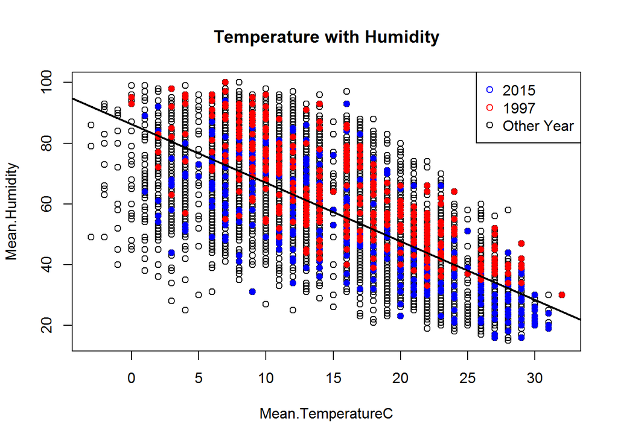

```r
# 建立一個畫布，拿上面的例子來說
plot(x=weather$Mean.TemperatureC,      # X軸的值
     y=weather$Mean.Humidity,       # Y軸的值
     main="Temperature with Humidity",    # 圖片名稱
     xlab="Mean.TemperatureC",       # X軸的名稱
     ylab="Mean.Humidity"         # Y軸的名稱
)

# 現在我們要在這張圖片中，把2015年的資料點用藍色標註上去
data_2015 <- weather[weather$year==2015, ]   # 找出2015年的資料
  # 標上藍色的點
points(x=data_2015$Mean.TemperatureC,
       y=data_2015$Mean.Humidity,
       pch=16,                  # 點的圖形
       col="blue")              # 顏色

# 同理，也可以把1997年的資料點用紅色標註上去
data_1997 <- weather[weather$year==1997, ]   # 找出1997年的資料
  # 標上紅色的點
points(x=data_1997$Mean.TemperatureC,
       y=data_1997$Mean.Humidity,
       pch=16,               # 點的圖形
       col="red")            # 顏色

# 在右上角做出圖例
legend("topright",                                # 表示在右上角
       pch = 1,                                   # pch代表點的圖案
       col = c("blue", "red", "black"),           # col代表顏色
       legend = c("2015", "1997", "Other Year") # 顏色所對應的名稱
       )

# 我們也可以畫出回歸趨勢線
lm.model <- lm(Mean.Humidity~Mean.TemperatureC, weather)    # 建立一個線性回歸
  # 畫上回歸的趨勢線
abline(lm.model,
       lwd=2)     # lwd 代表線的粗細
```

(上圖是集合所有動作的成果；建議初學者可以先在自己的電腦上，一步一步慢慢執行每一區段程式，就可以慢慢看見整張圖是如何增加或變化的~~)

你會發現，用`plot()`建立出一個散布圖(畫布)後，我們又運用一些函式，在畫布上面增添想要的資訊(e.g. `points()`=畫上點；`legend()`=作上圖例；`abline()`=畫上線)

當然，具有類似功能的函式不只這些，以下列出一些常用來增加的函式：

| 函式 | 功能 |
| --- | --- |
| plot | 繪製散布圖(畫布) |
| lines | 把資料點用線連接 |
| points | 繪製新的資料點 |
| text | 補充文字說明在圖上 |
| title | 補充主旨 |
| mtext | 在圖外顯示大主旨 |
| axis | 增加軸的labels |

而當我們會想要同時畫兩張甚至是多張圖時，`par()`函式就可以派上用場了：

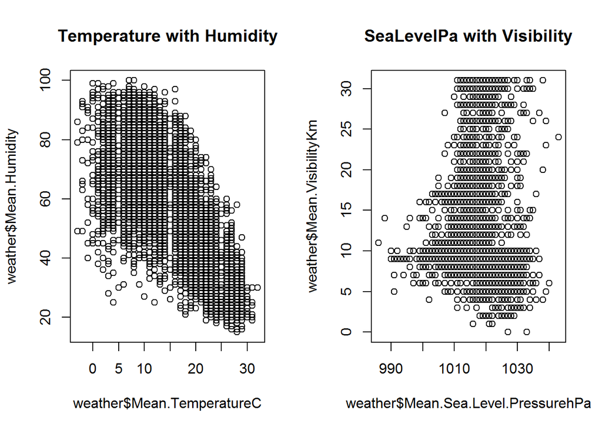

```r
# c(1,2)，表示建立一個1x2的空間，用來呈現後續的圖
par(mfrow = c(1,2)) # Left = row, Right = column

# 第一張圖
plot(weather$Mean.TemperatureC, weather$Mean.Humidity, main = "Temperature with Humidity")
# 第二張圖
plot(weather$Mean.Sea.Level.PressurehPa, weather$Mean.VisibilityKm
     , main = "SeaLevelPa with Visibility")
```

# **2. lattice**

這裡關於lattice的使用方式，就先不贅述了，有興趣的可以參考如下的網站~ [lattice](http://www.magesblog.com/2012/12/changing-colours-and-legends-in-lattice.html)

# **3. ggplot2**

接下來要介紹的，是在R裡面變化做多、色彩最豐的第三方繪圖套件：**ggplot2**。

`ggplot2`的繪圖概念，又和上面兩者不一樣，是基於*Grammar of Graphics* 的想法，直譯來說，就是「圖形的文法」。

簡單來說，就是當你在用`ggplot2`繪圖的時候，要思考圖形(graphics)中的**「名詞(noun)」、「動詞(verb)」、「形容詞(adjective)」**等，就是所謂的文法！

在`ggplot2`中，繪圖的文法包括兩個主要屬性：

- Aesthetic attributes (美學表現)：包括「顏色、形狀、點的大小與線的粗細」等…
- Geometric objects (幾何屬性)：包括「點、線、盒狀圖、直條圖」等…

此外，還有其他次要屬性：

- Facets：提供在同一張圖內做多個子圖的方法，只要使用Faceting功能設定子圖分類的依據參數即可。
- Stats：將資料做統計轉換。
- Scales：修改點線的顏色、形狀、xy軸的範圍等

使用ggplot2時，需要匯入`ggplot2`的套件，再根據以下步驟進行繪圖：

## ‧qplot()

這是`ggplot2`裡面比較簡易的函式，使用上很像`plot()`的觀念，不同的是，我們可以單純利用這個函式，改變其中`geom`的參數，就能畫出*直方圖、散佈圖、合鬚圖*等圖形。

### **直方圖(histogram)**

這裡，我們換一個內建資料庫裡的表單來示範:

```r
library(datasets)
head(airquality)
```

```
##   Ozone Solar.R Wind Temp Month Day
## 1    41     190  7.4   67     5   1
## 2    36     118  8.0   72     5   2
## 3    12     149 12.6   74     5   3
## 4    18     313 11.5   62     5   4
## 5    NA      NA 14.3   56     5   5
## 6    28      NA 14.9   66     5   6
```

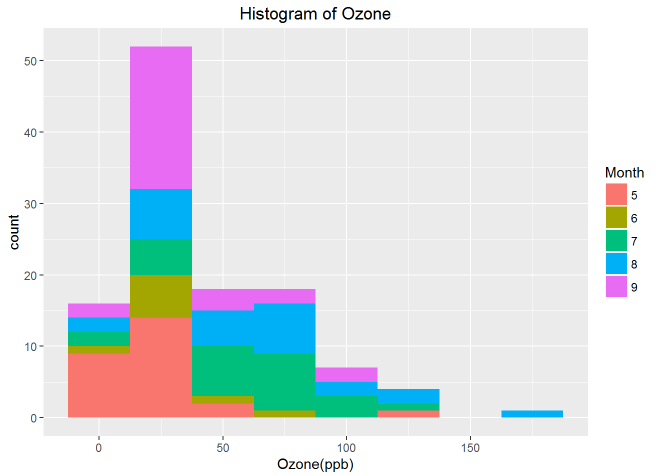

```r
require(ggplot2)
qplot(x=Ozone,
      data=airquality,
      geom="histogram",             # 圖形=histogram
      main = "Histogram of Ozone",
      xlab="Ozone(ppb)",
      binwidth = 25,                # 每25單位為一區隔
      fill = Month                   # 以顏色標註月份，複合式的直方圖
      )
```

### **散布圖(scatter plot)**

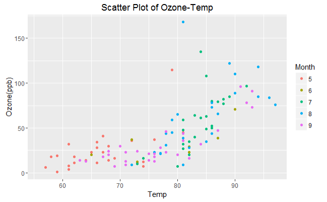

```r
qplot(x=Temp,
      y=Ozone,
      data=airquality,
      geom="point",                         # 圖形=scatter plot
      main = "Scatter Plot of Ozone-Temp",
      xlab="Temp",
      ylab="Ozone(ppb)",
      colour= Month                          # 以顏色標註月份，複合式的散布圖
      )
```

這邊注意到兩張圖的geom，分別是`histogram`以及`point`，這代表兩張圖主要呈現的**幾何方式**是不同的~  
接著，我們再來試試看另外兩種的幾何呈現方式~

### **機率密度圖(density plot)**

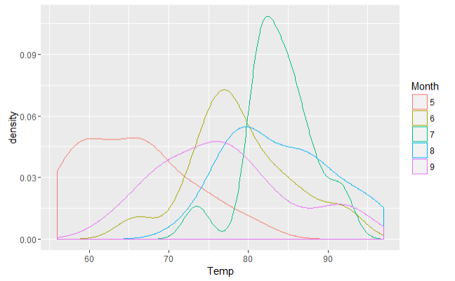

```r
qplot(x=Temp,
      data=airquality,
      geom="density",        # 圖形=density
      xlab="Temp",
      color= Month           # 以顏色標註月份，複合式的機率密度圖
)
```

### **合鬚圖(boxplot)**

[figure not shown]

```r
qplot(x=Month,
      y=Temp,
      data=airquality,
      geom="boxplot",       # 圖形=boxplot
      xlab="Month",
      colour= Month     # 以顏色標註月份，複合式的合鬚圖
)
```

`qplot()`裡面因為有許多內建的參數，因此使用起來，會讓人覺得很像是`plot()`或Lattice的繪圖函式。然而，卻也因為是內建的參數，有時候在使用`qplot()`時，會覺得有些受到限制。

因此，在`ggplot2`裡面，有另外一個函式叫做`ggplot()`，就是使用**「圖形的文法」**來進行繪圖。

比起`qplot()`，使用`ggplot()`需要自己進行各種設定(美學/幾何)，雖然學習上比較複雜一點，卻也因此更加有*彈性(flexible)*和*客製化(customized)*的表現。